# ISDS 4070/7070 Project - World Happiness Index

Louis Bergan, Andrew Grefer, Michael Hernandez, and Sina Sedaghat Baghbani

5/10/2022

# **Introduction**

For our group project, we decided to create research questions and attempt to answer them pertaining to the World Happiness Report. The World Happiness Report is a landmark survey of the state of global happiness that ranks 156 countries by how happy their citizens perceive themselves to be. The World Happiness Report 2020 for the first time ranks cities around the world by their subjective well-being and digs more deeply into how the social, urban and natural environments combine to affect our happiness. The Happiness Score is a national average of the responses to the main life evaluation question asked in the Gallup World Poll (GWP), which uses the Cantril Ladder. The Happiness Score is explained by the following factors: GDP per capita, Healthy Life Expectancy, Social support, Freedom to make life choices, Generosity, Corruption Perception.

Here are some of the most pertinent insights from the analysis that are of interest: 1. The variables Social Support and Freedom are the most significant when it comes to the Happiness Score. However, Generosity is not even important. 2. A higher GDP per capita strongly correlates with a higher life expectancy. 3. Preliminary analysis does not show any rise in perceived corruption and actually shows a decrease in 2021 compared to 2019.

Lastly, below are the research questions that we intend to answer with our analysis.

## Louis Bergan

1. Does a higher GDP relate to a higher healthy life expectancy?
2. Is there a relationship between each country’s ladder score and social support?

## Andrew Grefer

3. What are the most important variables when it comes to world happiness?
4. How is trust in the government and personal freedom correlated?

## Micheal Hernandez

5. Can we see a noticeable change of a countries Freedom to make Life choices during COVID years?
6. Do any countries show an increased Perception of Corruption during COVID years?

## Sina Sedaghat Baghbani

7. Is pre-COVID (2017-2019) happiness score significantly lower than post-COVID (2020-2022)?
8. Is the mean happiness score among regions significantly different pre- and post-COVID?

# **Analysis and Insights**

## 1. Does a higher GDP relate to a higher healthy life expectancy?

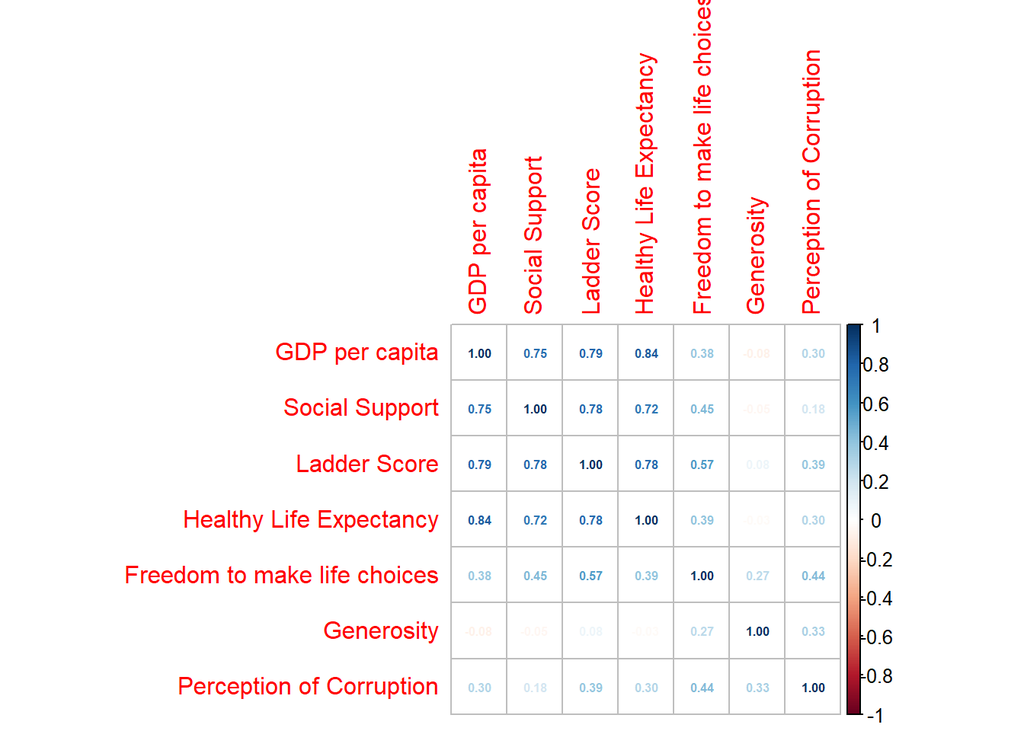

After observing how correlated these variables were, I plotted the data. Here, I plotted GDP per capita with Healthy Life Expectancy.

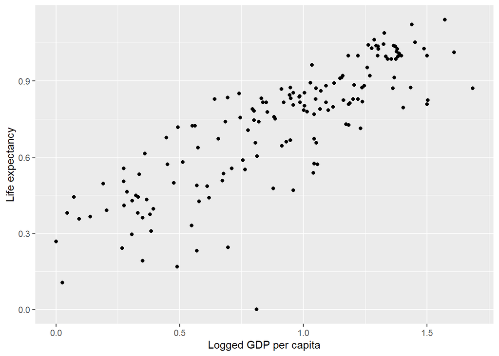

## 2. Is there a relationship between each country’s ladder score and social support?

Plotting Social support and Ladder Score. Ladder score is a metric that measured the perceived ability of citizens to improve their social conditions. Here, it can be seen that there is a visual correlation.

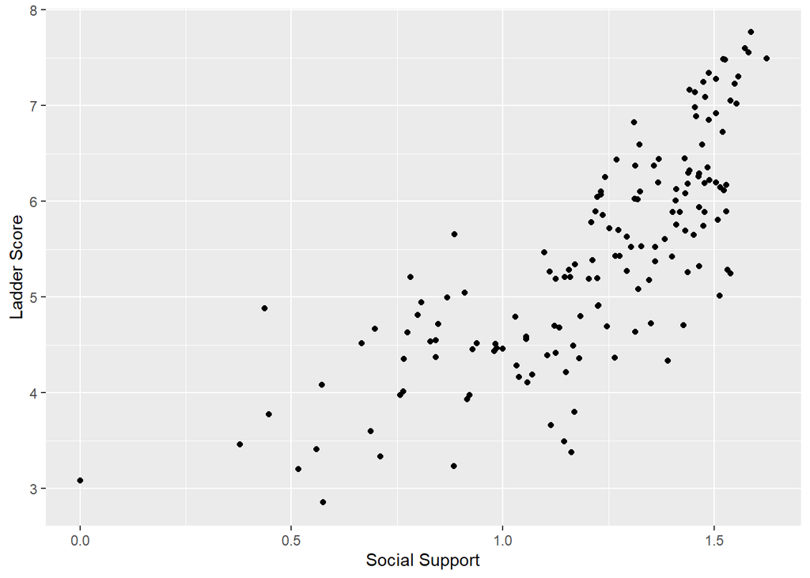

## 3. What are the most important variables when it comes to world happiness?

To answer this question, a linear regression was run on the data for the year of 2019. Im this year, it appeared the significant variables, in order from most to least, are: SocailSupport, FreedomToMakeLifeChoices, GDPperCapita, HealthyLifeExpectancy, and PerceptionsofCorruption. The variable Generosity was not significant when choosing all variables to be put into the model. The variables that are in the final model all have a positive coefficient, which makes sense for most of them. For example, it is common sense to understand that an increase in freedom would lead to an increase in happiness. However, PerceptionsofCorruption is a weird variable name since it seems like the higher the score, the more the country is perceived as corrupt by its citizens. This is not the case, though. The way to think about it is that the higher the ‘PerceptionsofCorruption’ is, the more citizens trust their country. That is why the estimate is positive for that variable. The more citizens trust their country, the happier they tend to be.

```
##
## Call:
## lm(formula = Score ~ GDP.per.capita + Social.support + Healthy.life.expectancy +
##     Freedom.to.make.life.choices + Perceptions.of.corruption,
##     data = df_2019)
##
## Residuals:
##      Min       1Q   Median       3Q      Max
## -1.82997 -0.35344  0.05803  0.35977  1.17522
##
## Coefficients:
##                              Estimate Std. Error t value Pr(>|t|)
## (Intercept)                    1.8689     0.1973   9.471  < 2e-16 ***
## GDP.per.capita                 0.7455     0.2161   3.450 0.000728 ***
## Social.support                 1.1180     0.2368   4.722 5.33e-06 ***
## Healthy.life.expectancy        1.0840     0.3344   3.241 0.001467 **
## Freedom.to.make.life.choices   1.5340     0.3666   4.185 4.84e-05 ***
## Perceptions.of.corruption      1.1176     0.5218   2.142 0.033839 *
## ---
## Signif. codes:  0 '***' 0.001 '**' 0.01 '*' 0.05 '.' 0.1 ' ' 1
##
## Residual standard error: 0.5335 on 150 degrees of freedom
## Multiple R-squared:  0.7777, Adjusted R-squared:  0.7703
## F-statistic:   105 on 5 and 150 DF,  p-value: < 2.2e-16
```

## 4. How is trust in the government and personal freedom correlated?

For this research question, I created a scatter plot to show any trends between the variables FreedomToMakeLifeChoices and PerceptionsOfCorruption. Again, this is using the 2019 data. In the graph below, a clear positive, although non-linear, trend is evident in the data between the two variables. When an actual calculation is done between the two variables, they have a correlation of **0.4388433**. This is considered a moderate strength correlation, but we have to keep in mind that correlation does not always mean causation. Therefore, we can’t definitively say that less freedom means less trust in the government. More statistical analyses would have to be conducted to prove that.

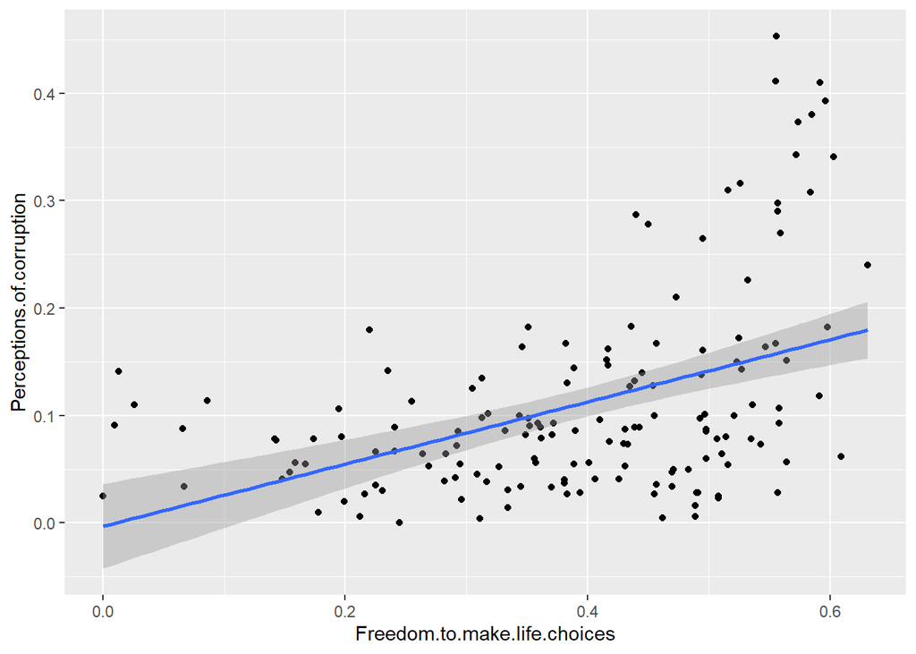

For this question I first decided to restrict my datasets to only the top fifty countries to keep the graph readable. Then I created a scatterplot that graphs cercieved corruption against the Happiness score. I did this for the years 2018-2021 so that we could get a nice spread of pre-covid and post-covid years. With the way these scores are aggregated to reach the happiness score, the greater the slope the lower the percieved corruption. the graphs also show a clear correlation between lower percieved corruption and a higher happiness score. The graph shows that there was no increase in percieved corruption, and in fact countries percieved their countries as less corrupt post Covid.

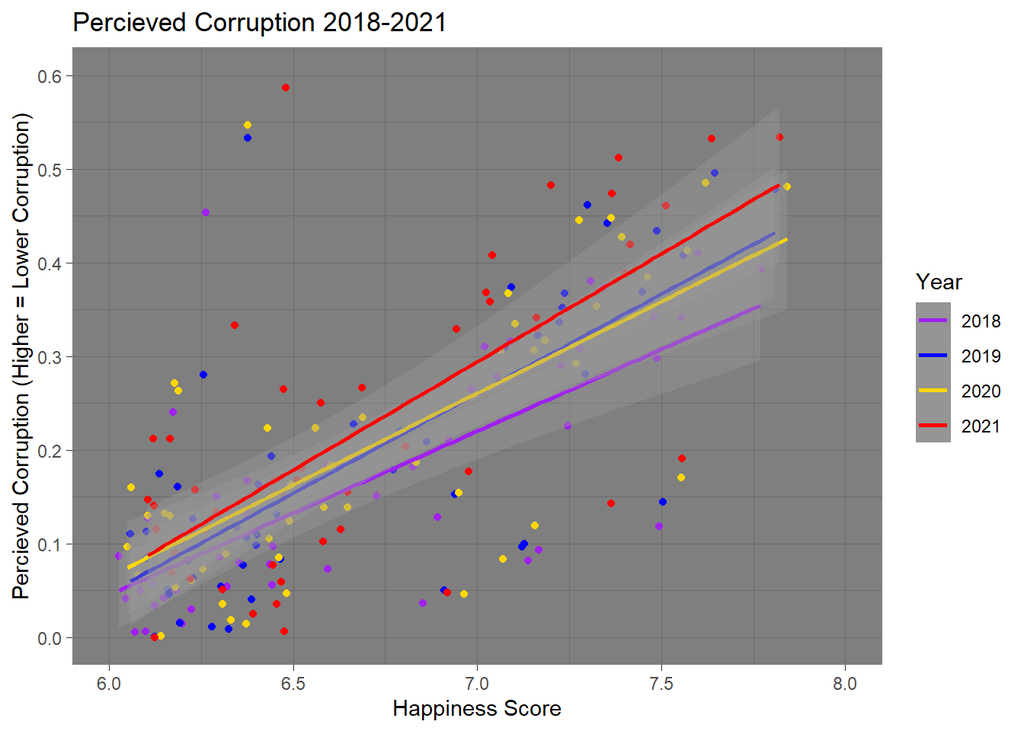

Like the corruption question, I decided to limit these to the top fifty happiest countries every year. For this one I decided to to graph the Freedom to make life choices variable against the happiness score. Looking at this, the first thing that we can see is that there is less variation in percieved freedom from number fifty to number one making for a fairly small slope. one thing we can also see is that percieved freedom has gone up every year since 2018. This shows that there is no percieved loss of freedoms and that countries believe that they have more freedom than they did three years ago.

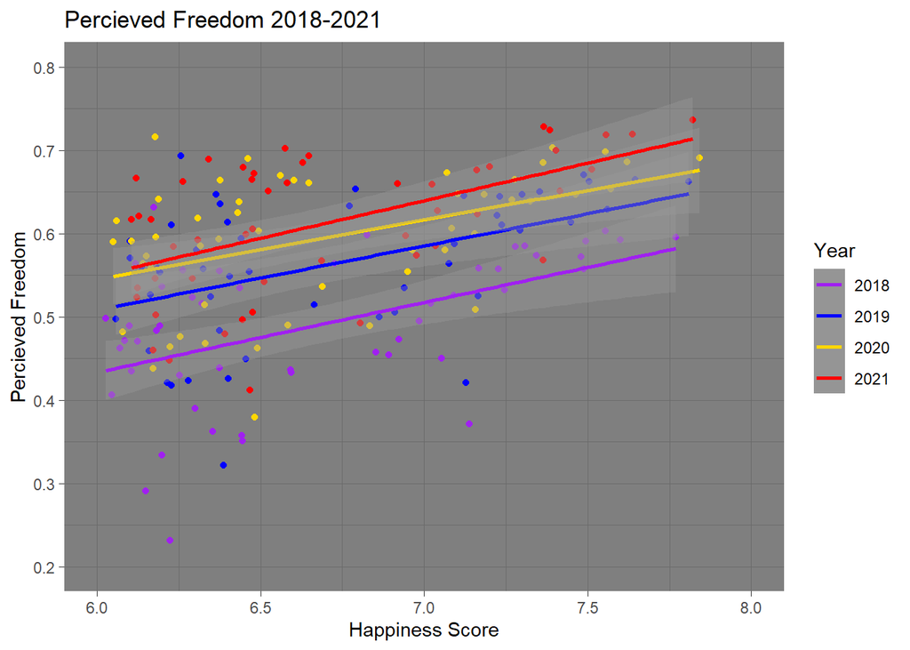

## 7. Is pre-COVID (2017-2019) happiness score significantly lower than post-COVID (2020-2022)?

### Data import

Please note that to avoid errors during the importation of a file into R and analysis based on it, I made sure that the dataset i used is well prepared. The datasets downloaded from Kaggle website was not clean so a long effort using MS Excel was done to clean about 10 types of data messiness (some of them required manual reentry of data!) and in some cases some useful columns were added to the raw databse. The csv file imported here is a cleaned version of the data available on Kaggle and the final version will be uploaded to Kaggle soon for community use.

### Normality tests

Here we do some preliminary tests to make sure that the test assumptions are met. Since the sample size is large enough (n > 30), we can ignore the distribution of the data and use parametric tests. However, to be consistent, we are checking normality by visual inspection and by significance tests. I used Density plot and Q-Q plot to check normality visually. For checking by significance test (Shapiro-Wilk’s test) the null hypothesis is that “sample distribution is normal”. If the test is significant, the distribution is non-normal.

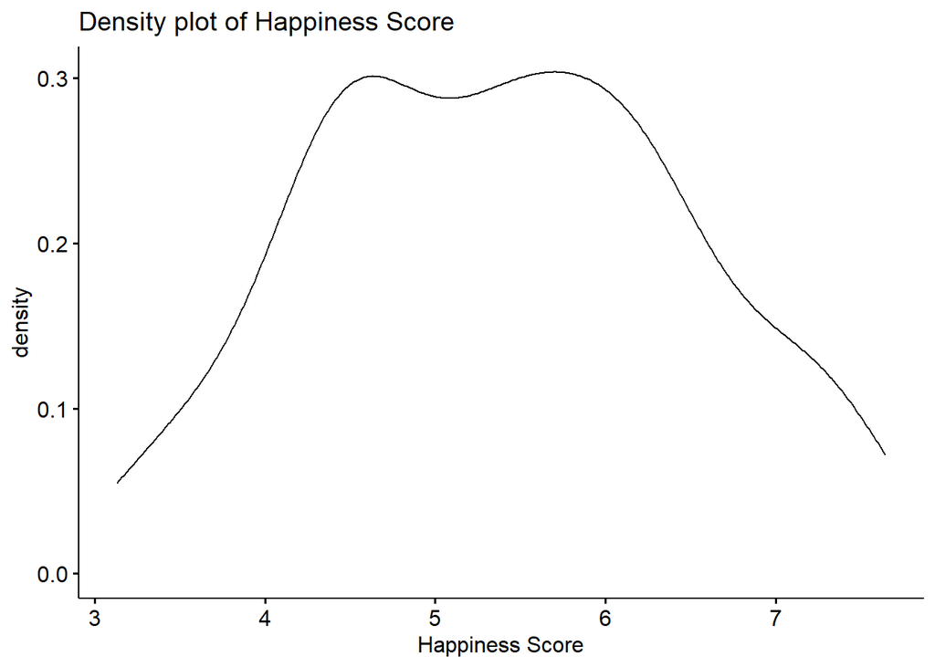

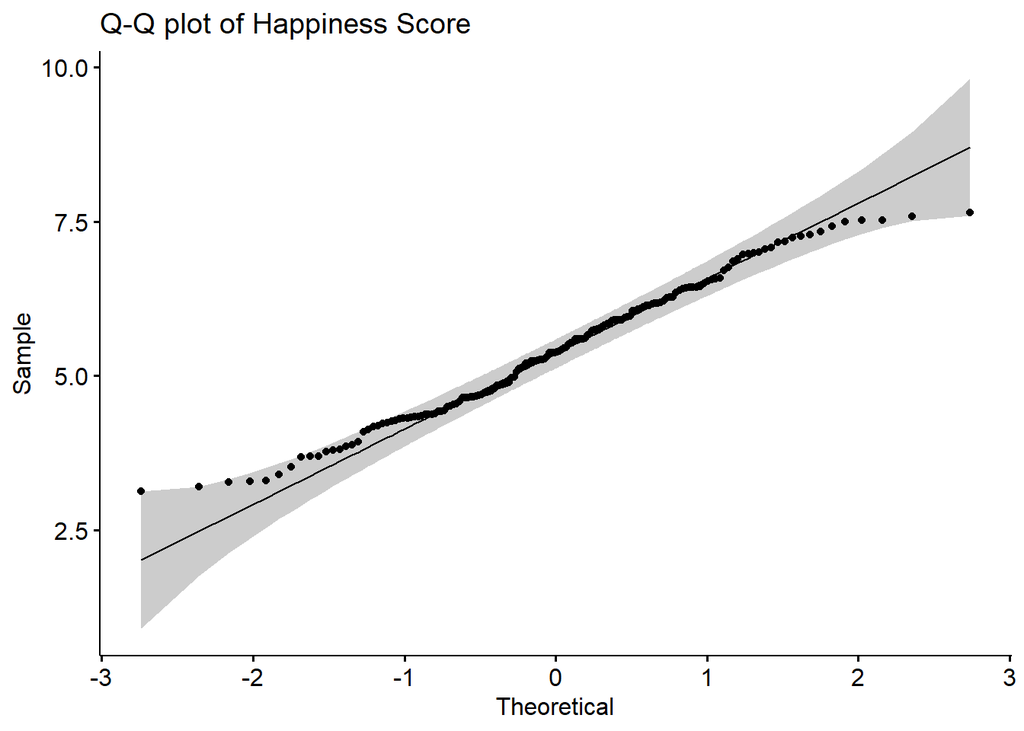

According to the output of visual tests, since all the points fall approximately along the reference line, we can assume normality. According to the output of Shapiro-Wilk normality test since the p-value of 0.0436669 < “0.05” implying that the distribution of the data are significantly different from normal distribution. In other words, we cannot assume the normality which makes sense since the data is on countries’ happiness score among different years and the population and sample are almost the same.

### Data handling

Now since the analysis I want to do in my questions requires happiness index score of countries from 2017 to 2022, I need to exclude countries that lack data on any of these years. For this purpose, I need to select part of the data I imported and identify the observations I need to exclude.

### Paired T-test

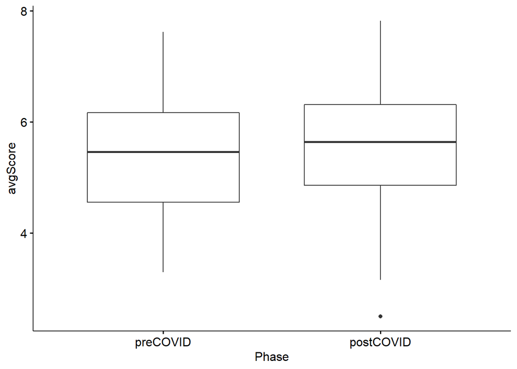

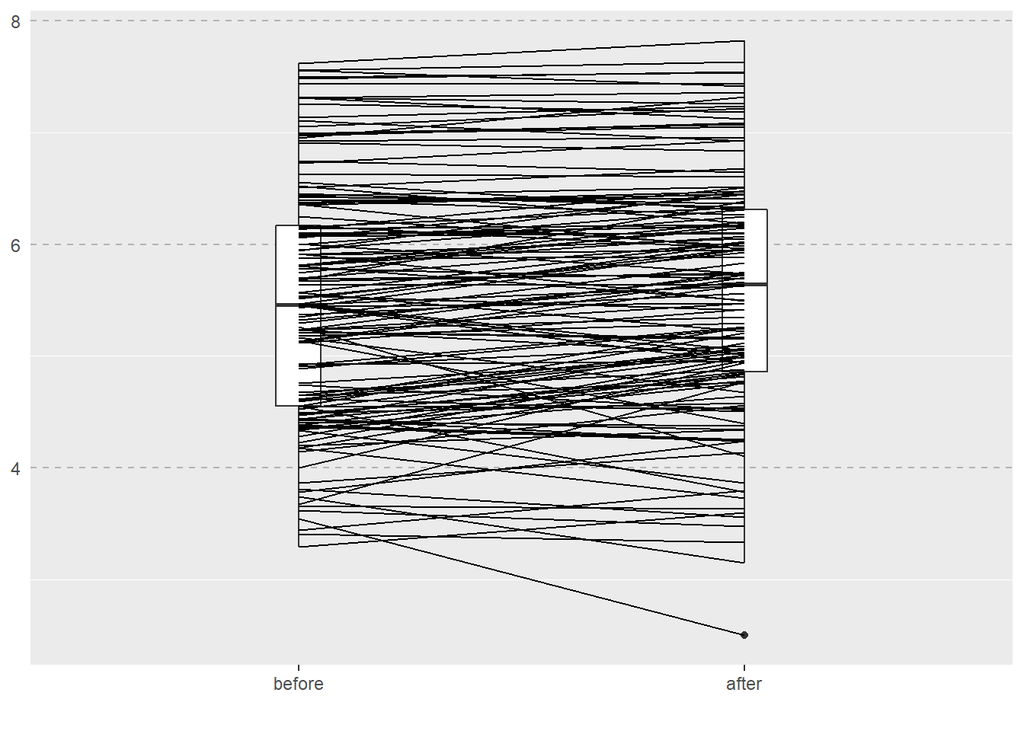

## 8. Is the mean happiness score among regions significantly different pre- and post-COVID?

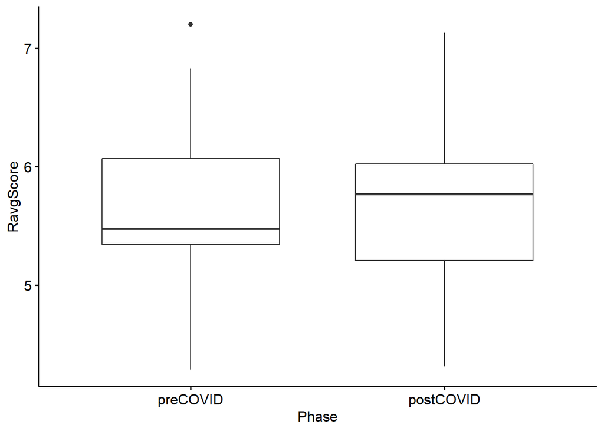

[figure not shown]

# Appendix

**3. What are the most important variables when it comes to world happiness?**

3.1 The variable selection for the model used to answer this question was based on the backward selection technique. This means that all variables were used at first and they were paired down by which variable had the highest p-value at each iteration. This was done until all the variables in the model had a p-value of less than 0.05. On the first iteration, as seen below, Generosity had the highest p-value, and was not significant, so it was removed before the next iteration. On the second iteration, in the analysis section above, all variables were significant and the variable selection process was stopped.

```
##
## Call:
## lm(formula = Score ~ GDP.per.capita + Social.support + Healthy.life.expectancy +
##     Freedom.to.make.life.choices + Generosity + Perceptions.of.corruption,
##     data = df_2019)
##
## Residuals:
##      Min       1Q   Median       3Q      Max
## -1.75304 -0.35306  0.05703  0.36695  1.19059
##
## Coefficients:
##                              Estimate Std. Error t value Pr(>|t|)
## (Intercept)                    1.7952     0.2111   8.505 1.77e-14 ***
## GDP.per.capita                 0.7754     0.2182   3.553 0.000510 ***
## Social.support                 1.1242     0.2369   4.745 4.83e-06 ***
## Healthy.life.expectancy        1.0781     0.3345   3.223 0.001560 **
## Freedom.to.make.life.choices   1.4548     0.3753   3.876 0.000159 ***
## Generosity                     0.4898     0.4977   0.984 0.326709
## Perceptions.of.corruption      0.9723     0.5424   1.793 0.075053 .
## ---
## Signif. codes:  0 '***' 0.001 '**' 0.01 '*' 0.05 '.' 0.1 ' ' 1
##
## Residual standard error: 0.5335 on 149 degrees of freedom
## Multiple R-squared:  0.7792, Adjusted R-squared:  0.7703
## F-statistic: 87.62 on 6 and 149 DF,  p-value: < 2.2e-16
```

3.2 Looking at the diagnostic plots for the linear model that was used for the analysis, there could be some potential problems with said model. First, studying the Residuals vs Fitted plot, one would ideally want to see the points be scatted around the plot equally, around the middle line and evenly from left to right. This is what is observed for the most part. There are no clear patterns such as an exponential function or fan-like shape, which would be an automatic violation of linearity. An argument could be made for unequal error variances, but it is not obvious from this graph. Moving onto the Q-Q plot, the observations follow the diagonal line for the most part except for at the extremes, especially at the lower end. Again, an argument could be made for a non-normal distribution, but more statistical analysis would have to be done to be sure. For the Scale-Location plot, homoscedasticity does not appear to be violated. Also, on the Residuals vs Leverage plot, there are no weird trends with the data or any observations that are outliers or have significantly high leverage. Overall, the model seems to be following all the assumptions of a linear model, but some transformations could be conducted to improve it.

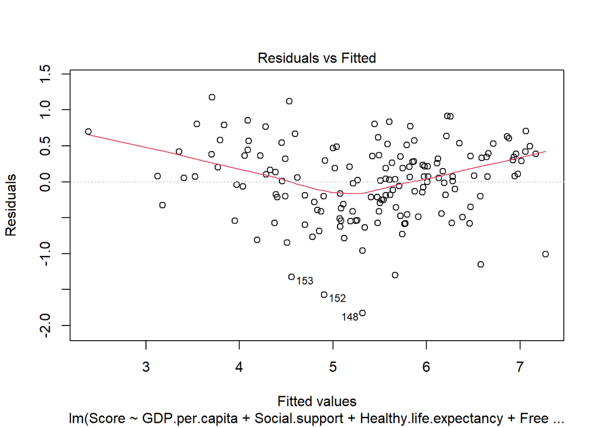

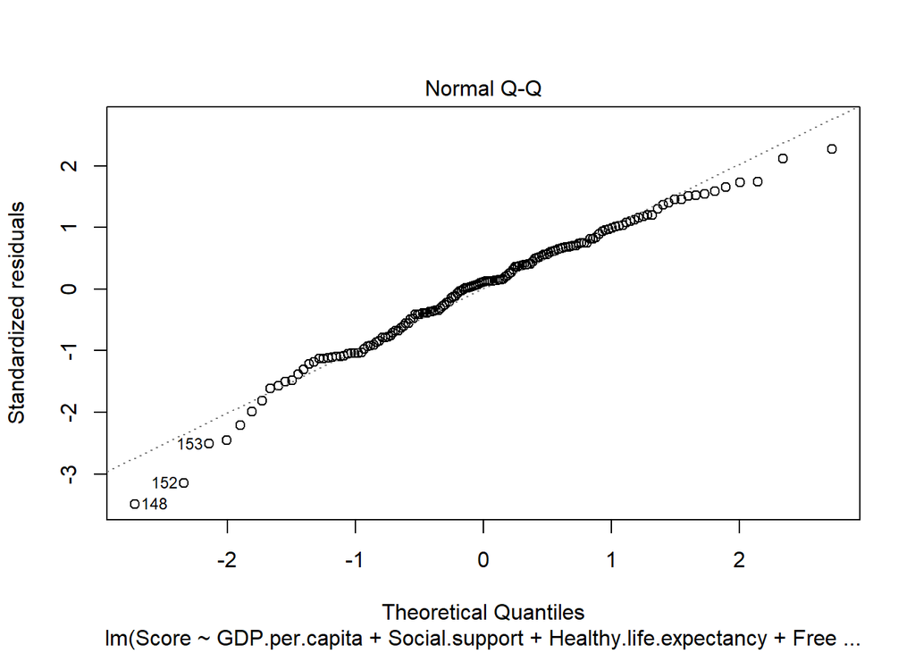

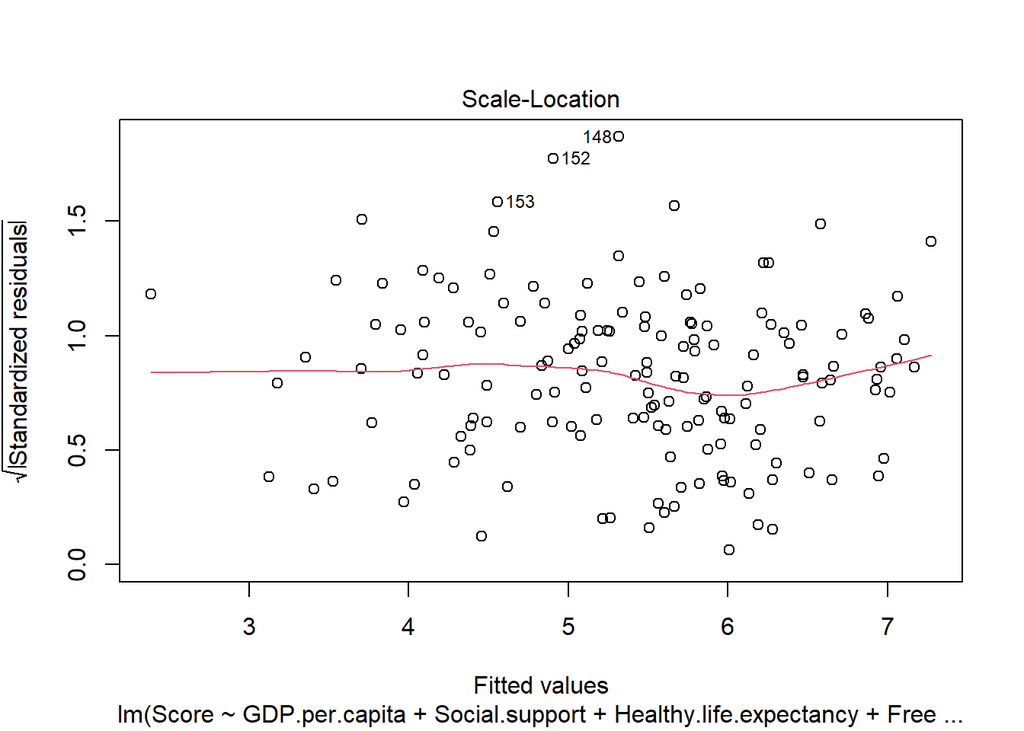

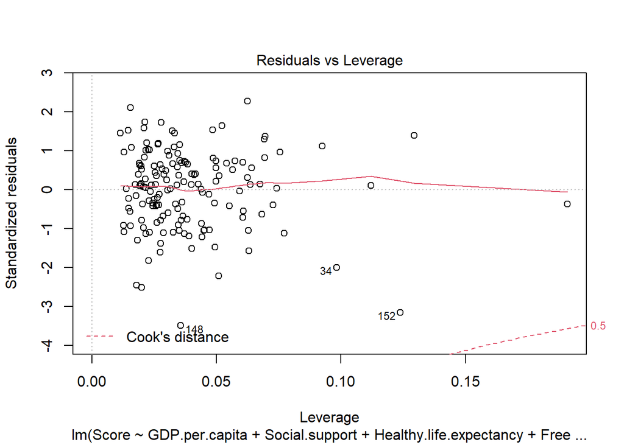